# STAT420 HW1

# Exercise 1 (Using lm)

For this exercise we will use the cats dataset from the MASS package. You should use ?cats to learn about the background of this dataset.

**(a)** Suppose we would like to understand the size of a cat’s heart based on the body weight of a cat. Fit a simple linear model in R that accomplishes this task. Store the results in a variable called cat_model. Output the result of calling summary() on cat_model

```r
library(MASS)
cat_lm<-lm(Hwt~Bwt, data=cats)
summary(cat_lm)
```

```
##
## Call:
## lm(formula = Hwt ~ Bwt, data = cats)
##
## Residuals:
##     Min      1Q  Median      3Q     Max
## -3.5694 -0.9634 -0.0921  1.0426  5.1238
##
## Coefficients:
##             Estimate Std. Error t value Pr(>|t|)
## (Intercept)  -0.3567     0.6923  -0.515    0.607
## Bwt           4.0341     0.2503  16.119   <2e-16 ***
## ---
## Signif. codes:  0 '***' 0.001 '**' 0.01 '*' 0.05 '.' 0.1 ' ' 1
##
## Residual standard error: 1.452 on 142 degrees of freedom
## Multiple R-squared:  0.6466, Adjusted R-squared:  0.6441
## F-statistic: 259.8 on 1 and 142 DF,  p-value: < 2.2e-16
```

**(b)** Output only the estimated regression coefficients. Interpret β0^ and β1 in the context of the problem. Be aware that only one of those is an estimate.

```r
coef(cat_lm)
```

```
## (Intercept)         Bwt
##  -0.3566624   4.0340627
```

**(c)** Use your model to predict the heart weight of a cat that weights 2.7 kg. Do you feel confident in this prediction? Briefly explain.

```r
range(cats$Bwt)
```

```
## [1] 2.0 3.9
```

```r
beta0 <- coef(cat_lm)[1]
beta1 <- coef(cat_lm)[2]
print(beta0+beta1*2.7)
```

```
## (Intercept)
##    10.53531
```

**(d)** Use your model to predict the heart weight of a cat that weights 4.4 kg. Do you feel confident in this prediction? Briefly explain.

```r
predict(cat_lm, data.frame(Bwt=4.4))
```

```
##        1
## 17.39321
```

**(e)** Create a scatterplot of the data and add the fitted regression line. Make sure your plot is well labeled and is somewhat visually appealing.

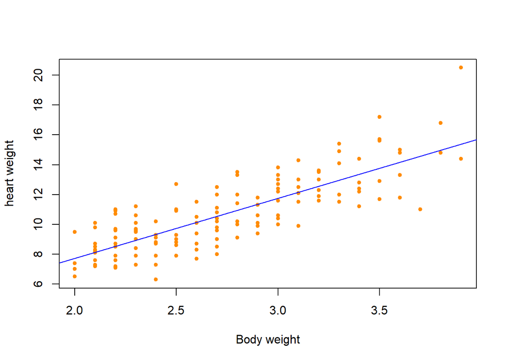

```r
plot(cats$Hwt~cats$Bwt, xlab='Body weight', ylab = 'heart weight', pch=20, col="darkorange")
abline(cat_lm, col="blue")
```

**(f)** Report the value of R2 for the model. Do so directly. Do not simply copy and paste the value from the full output in the console after running summary() in part (a).

```r
summary(cat_lm)$r.squared
```

```
## [1] 0.6466209
```

# Exercise 2 (Writing Functions)

**(a)** Write a function called get_sd_est that calculates an estimate of σ in one of two ways depending on input to the function. The function should take three arguments as input:

- fitted_vals - A vector of fitted values from a model
- actual_vals - A vector of the true values of the response
- mle - A logical (TRUE / FALSE) variable which defaults to FALSE The function should return a single value:

$s_e$ if mle is set to FALSE. $\hat\sigma$ if mle is set to TRUE.

```r
get_sd_est <- function(fitted_vals, actual_vals, mle){
  n = length(fitted_vals) - 2*!mle
  return (sqrt(sum((actual_vals-fitted_vals)^2)/n))
}
```

**(b)** Run the function get_sd_est on the residuals from the model in Exercise 1, with mle set to FALSE. Explain the resulting estimate in the context of the model.

```r
get_sd_est(cat_lm$fitted.values, cat_lm$model$Hwt, FALSE)
```

```
## [1] 1.452373
```

*(c)* Run the function get_sd_est on the residuals from the model in Exercise 1, with mle set to TRUE. Explain the resulting estimate in the context of the model. Note that we are trying to estimate the same parameter as in part (b).

```r
get_sd_est(cat_lm$fitted.values, cat_lm$model$Hwt, TRUE)
```

```
## [1] 1.442252
```

**(d)** To check your work, output summary(cat_model)$sigma. It should match at least one of (b) or (c).

```r
summary(cat_lm)$sigma
```

```
## [1] 1.452373
```

# Exercise 3(Simulating SLR)

```r
birthday = 18760613
set.seed(birthday)
x <- runif(n=25, 0,10)

sim_slr = function(x, beta_0 = 10, beta_1 = 5, sigma = 1) {
  n = length(x)
  epsilon = rnorm(n, mean = 0, sd = sigma)
  y = beta_0 + beta_1 * x + epsilon
  data.frame(predictor = x, response = y)
}

sim_data = sim_slr(x = x, beta_0 = 5, beta_1 = -3, sigma = 3.2)
sim_data
```

| predictor | response |
| --- | --- |
| 4.1122809 | -2.7049802 |
| 5.2708753 | -12.4568835 |
| 7.1392299 | -12.8351275 |
| 3.2923543 | -8.0252630 |
| 7.8169394 | -22.0854840 |
| 4.3534221 | -9.6577735 |
| 0.3067567 | -0.6930027 |
| 7.8808453 | -19.0525739 |
| 2.4832575 | -3.9010470 |
| 5.1456791 | -6.7146855 |

[output cut: 15 more lines]

**(b)** Fit a model to your simulated data. Report the estimated coefficients. Are they close to what you would expect? Briefly explain.

```r
sim_model <- lm(response~predictor, data=sim_data)
coef(sim_model)
```

```
## (Intercept)   predictor
##    4.954205   -2.915525
```

**(c)** Plot the data you simulated in part (a). Add the regression line from part (b) as well as the line for the true model. Hint: Keep all plotting commands in the same chunk.

[figure not shown]

```r
plot(sim_data, pch=20, col="gray")
abline(sim_model, col='blue', lty=2)
abline(5,-3, col="darkorange")
legend("topright", c("Estimate", "Truth"), lty = c(1, 2), lwd = 2,
       col = c("darkorange", "dodgerblue"))
```

**(d)** Use R to repeat the process of simulating n = 25 observations from the above model 1500 times. Each time fit a SLR model to the data and store the value of $\hat\beta_1$ in a variable called beta_hat_1. Some hints:

- Consider a for loop.
- Create beta_hat_1 before writing the for loop. Make it a vector of length 1500 where each element is 0.
- Inside the body of the for loop, simulate new y data each time. Use a variable to temporarily store this data together with the known x data as a data frame.
- After simulating the data, use lm() to fit a regression. Use a variable to temporarily store this output.
- Use the coef() function and [] to extract the correct estimated coefficient. *Use beta_hat_1[i] to store in elements of beta_hat_1.
- See the notes on Distribution of a Sample Mean for some inspiration. You can do this differently if you like. Use of these hints is not required.

```r
beta_hat_1=1:1500
for(i in 1:1500){
  sim_data = sim_slr(x = x, beta_0 = 5, beta_1 = -3, sigma = 3.2)
  beta_hat_1[i] <-  lm(response~predictor, data =sim_data)$coefficients[2]
}
```

**(e)** Report the mean and standard deviation of beta_hat_1. Do either of these look familiar?

```r
mean(beta_hat_1)
```

```
## [1] -2.995916
```

```r
sd(beta_hat_1)
```

```
## [1] 0.2501589
```

**(f)** Plot a histogram of beta_hat_1. Comment on the shape of this histogram.

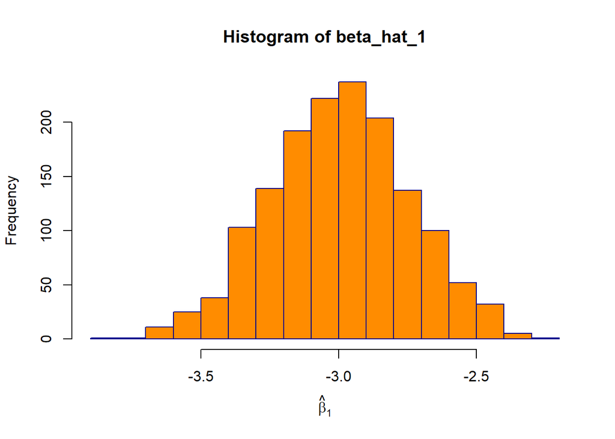

```r
hist(beta_hat_1, xlab=expression(hat(beta)[1]), col="darkorange", border='darkblue')
```

# Exercise 4(Be a Skeptic)

$$Y_i = 3+0*x_i+\epsilon_i$$
with
$$\epsilon_i ~N(\mu=0, \sigma^2=4)$$

where $\beta_0$ =3 and $\beta_1$= 0

```r
birthday = 18760613
set.seed(birthday)
```

**(a)** Use R to repeat the process of simulating n = 75 observations from the above model 2500 times. For the remainder of this exercise, use the following “known” values of x.

```r
x = runif(n=75, 0, 10)
beta_hat_1 = 1:2500
for(i in 1:2500){
  sim_data = sim_slr(x, beta_0 = 3, beta_1 = 0, sigma = 2)
  beta_hat_1[i]=lm(response~predictor, data=sim_data)$coefficients[2]
}
```

**(b)** Plot a histogram of beta_hat_1. Comment on the shape of this histogram.

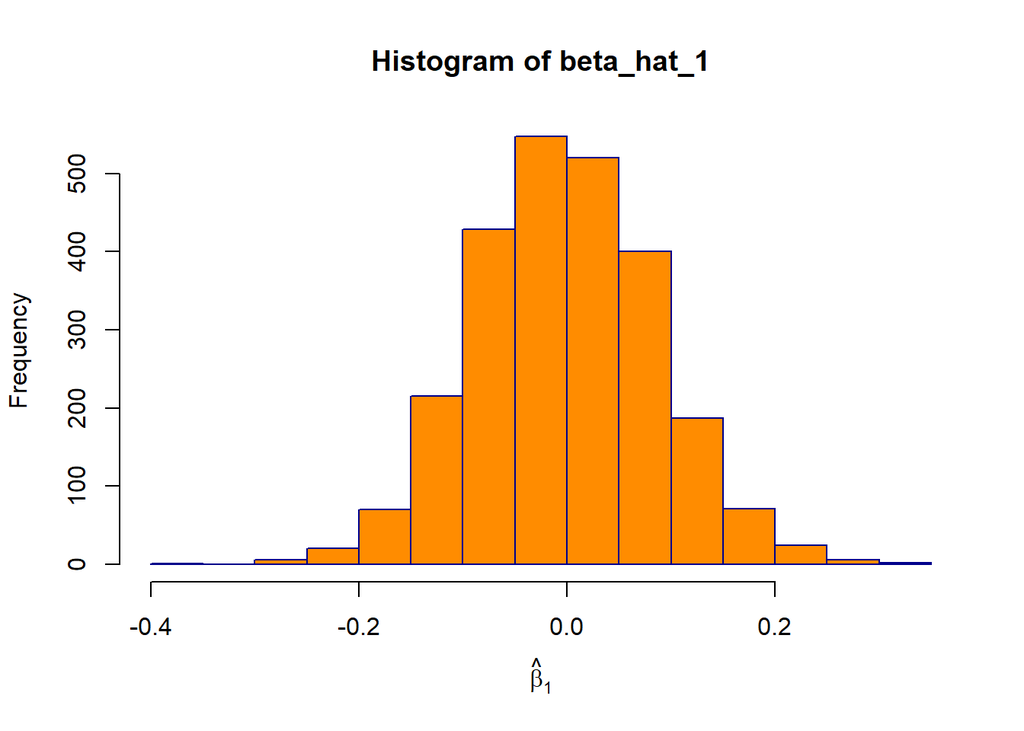

```r
hist(beta_hat_1, xlab=expression(hat(beta)[1]), col="darkorange", border='darkblue')
```

```r
setwd(".")
data <- read.csv("skeptic.csv")
```

# Exercise 5(Comparing Models)

For this exercise we will use the Ozone dataset from the mlbench package. You should use ?Ozone to learn about the background of this dataset. You may need to install the mlbench package. If you do so, do not include code to install the package in your R Markdown document. For simplicity, we will perform some data cleaning before proceeding.

```r
data(Ozone, package = "mlbench")
Ozone = Ozone[, c(4, 6, 7, 8)]
colnames(Ozone) = c("ozone", "wind", "humidity", "temp")
Ozone = Ozone[complete.cases(Ozone), ]
```

We have:

**(a)** Fit three SLR models, each with “ozone” as the response. For the predictor, use “wind speed,” “humidity percentage,” and “temperature” respectively. For each, calculate RMSE and R2. Arrange the results in a markdown table, with a row for each model. Suggestion: Create a data frame that stores the results, then investigate the kable() function from the knitr package.

```r
wind_lm <-lm(ozone~wind, data=Ozone)
hum_lm <-lm(ozone~humidity, data=Ozone)
temp_lm <-lm(ozone~temp, data=Ozone)
y <- Ozone$ozone

get_rmse <- function(model){
  sqrt(mean(resid(model)^2))
}

get_r2 <- function(model){
  summary(model)$r.squared
}

# create list of model
mod_list <- list(wind_lm, hum_lm, temp_lm)

# obtain results
results = data.frame(
  Predictor= c("wind", "humidity", "temp"),
  RMSE = sapply(mod_list, get_rmse),
  R2 = sapply(mod_list, get_r2)
)

# create markdown table of results
knitr::kable(results)
```

| Predictor | RMSE | R2 |
| --- | --- | --- |
| wind | 7.961695 | 0.0001402 |
| humidity | 7.147822 | 0.1941105 |
| temp | 5.009257 | 0.6042011 |